# Praktikum 5 - Pemeriksaan Kestasioneran Data

Angel Martha Pradina Pangaribuan

2023-09-26

```r
library(ggplot2)
library(tsibble)
library(tseries)
library(MASS)
```

### Input Data

```r
library(rio)
stas <- import('https://raw.githubusercontent.com/AngelMartha/PraktikumMPDW/main/P1/GOTO.JK.csv')
stas
```

```
##        Tanggal Open High Low Close Adj Close      Volume
## 1   2022-09-05  284  292 280   282       282   551653400
## 2   2022-09-06  286  290 282   282       282   418847200
## 3   2022-09-07  282  294 280   282       282  1078750900
## 4   2022-09-08  286  292 284   286       286  1297537200
## 5   2022-09-09  288  290 278   282       282   722741900
## 6   2022-09-12  284  286 276   278       278   722425300
## 7   2022-09-13  280  284 276   276       276   646000200
## 8   2022-09-14  272  278 268   272       272   942221600
## 9   2022-09-15  274  276 266   266       266  1309751800
## 10  2022-09-16  266  266 248   248       248  1907902100
## 11  2022-09-19  248  248 234   242       242  1180390700
## 12  2022-09-20  244  268 244   266       266  1631009500
## 13  2022-09-21  268  272 256   264       264   478347600
## 14  2022-09-22  260  264 256   264       264   316075300
```

[output cut: 228 more lines]

```r
stas <- stas$Close
```

### Plot *Time Series*

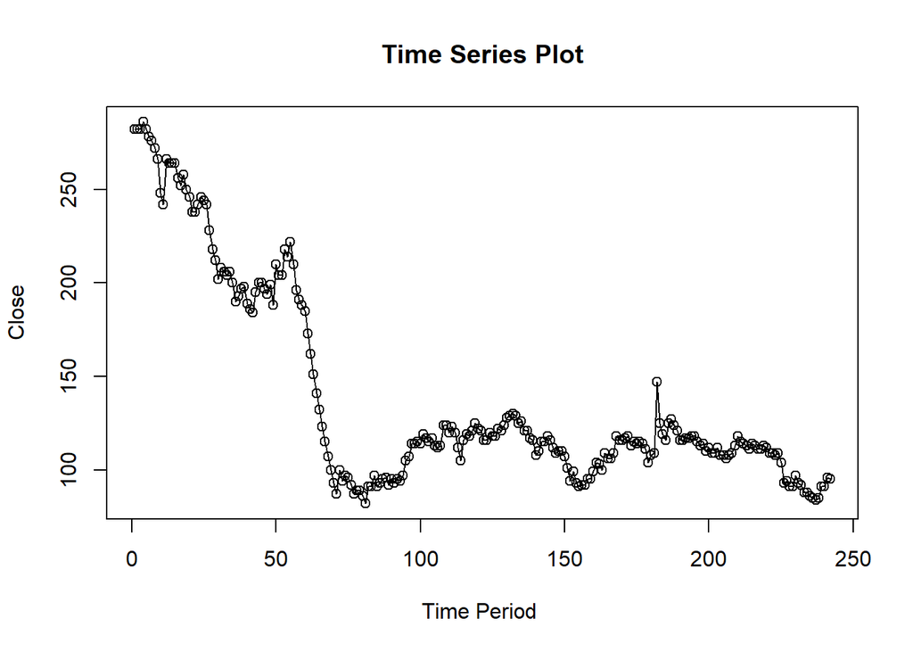

```r
plot_stas <- ts.plot(stas, xlab="Time Period ", ylab="Close",
        main = "Time Series Plot")
points(stas)
```

Plot deret waktu di atas menunjukkan bahwa data dari 0 - 70 menunjukkan tren negatif dan sisanya tidak stasioner dalam rataan, ditandai dengan lebar pita yang cenderung berbeda.

### Plot ACF

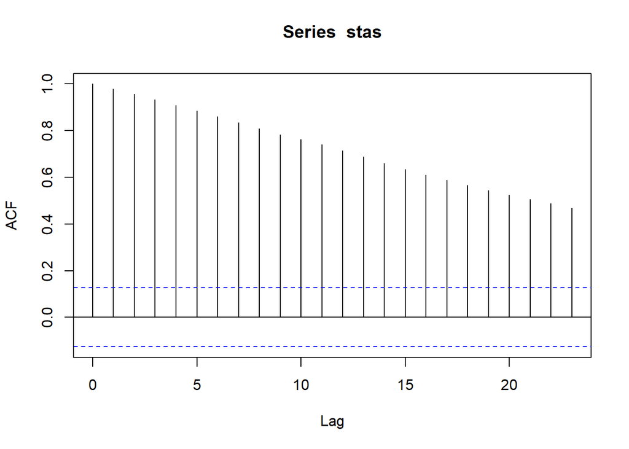

```r
acf(stas)
```

Berdasarkan plot ACF, terlihat bahwa plot ACF pada data tersebut cenderung *tails off* sehingga mengindikasikan tidak stasioner.

### Uji ADF

```r
tseries::adf.test(stas)
```

```
##
##  Augmented Dickey-Fuller Test
##
## data:  stas
## Dickey-Fuller = -2.3793, Lag order = 6, p-value = 0.4163
## alternative hypothesis: stationary
```

$H_0$ : Data tidak stasioner dalam rataan

$H_1$ : Data stasioner dalam rataan

Berdasarkan uji ADF tersebut, didapat *p-value* sebesar 0.4163 yang lebih besar dari taraf nyata 5% sehingga tak tolak $H_0$ dan menandakan bahwa data tidak stasioner dalam rataan. Hal ini sesuai dengan hasil eksplorasi menggunakan plot time series dan plot ACF.

### Plot Box-Cox

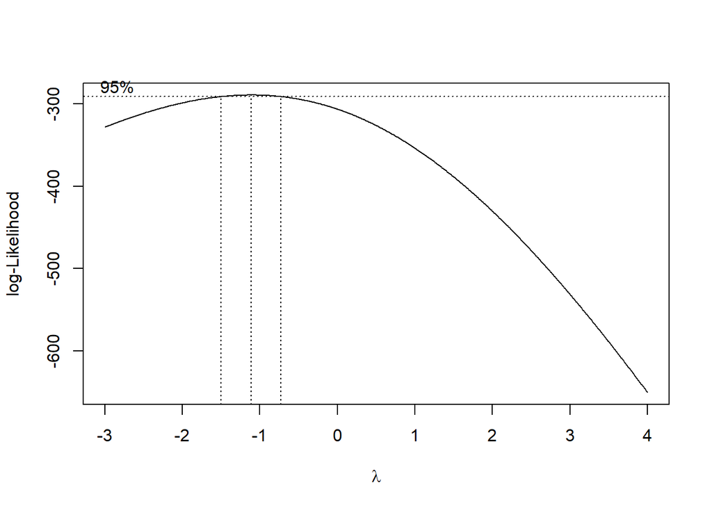

```r
index <- seq(1:242)
bc = boxcox(stas~index, lambda = seq(-3,4,by=0.01))
```

```r
#Nilai Rounded Lambda
lambda <- bc$x[which.max(bc$y)]
lambda
```

```
## [1] -1.11
```

```r
#SK
bc$x[bc$y > max(bc$y) - 1/2 * qchisq(.95,1)]
```

```
##  [1] -1.50 -1.49 -1.48 -1.47 -1.46 -1.45 -1.44 -1.43 -1.42 -1.41 -1.40 -1.39
## [13] -1.38 -1.37 -1.36 -1.35 -1.34 -1.33 -1.32 -1.31 -1.30 -1.29 -1.28 -1.27
## [25] -1.26 -1.25 -1.24 -1.23 -1.22 -1.21 -1.20 -1.19 -1.18 -1.17 -1.16 -1.15
## [37] -1.14 -1.13 -1.12 -1.11 -1.10 -1.09 -1.08 -1.07 -1.06 -1.05 -1.04 -1.03
## [49] -1.02 -1.01 -1.00 -0.99 -0.98 -0.97 -0.96 -0.95 -0.94 -0.93 -0.92 -0.91
## [61] -0.90 -0.89 -0.88 -0.87 -0.86 -0.85 -0.84 -0.83 -0.82 -0.81 -0.80 -0.79
## [73] -0.78 -0.77 -0.76 -0.75 -0.74
```

### Partisi Data

#### Bagian 1

```r
dt_stas1 <- stas[1:70] |> ts()
mean(dt_stas1)
```

```
## [1] 212.8429
```

```r
var(dt_stas1)
```

```
## [1] 2161.41
```

#### Plot Time Series

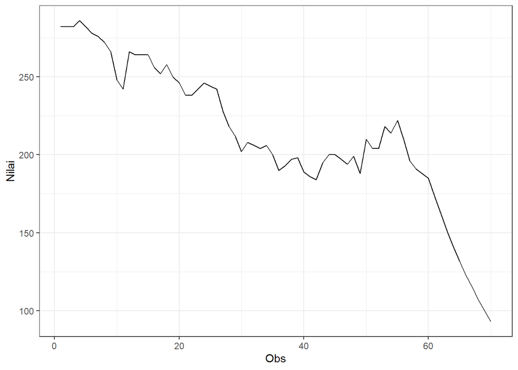

```r
dt_stas1 |> as_tsibble() |>
  ggplot(aes(x = index, y = value)) +
  geom_line() + theme_bw() +
  xlab("Obs") + ylab("Nilai")
```

Plot deret waktu di atas menunjukkan bahwa data tidak stasioner dalam rataan, ditandai dengan data yang tidak menyebar di sekitar nilai tengahnya. Selain itu, data cenderung tidak stasioner dalam ragam, ditandai dengan lebar pita yang cenderung berbeda.

#### Plot ACF

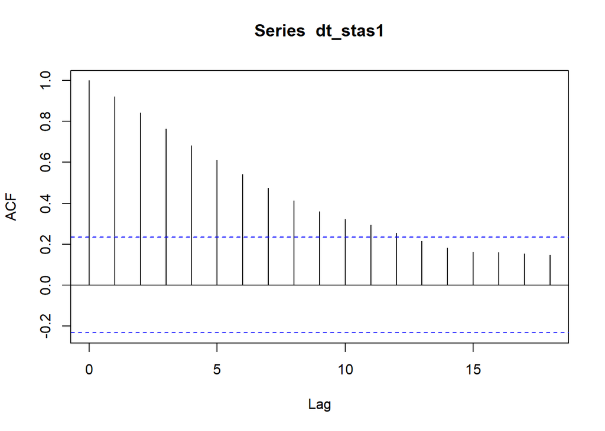

```r
acf(dt_stas1)
```

Berdasarkan plot ACF, terlihat bahwa plot ACF pada data tersebut cenderung *tails off* sehingga mengindikasikan tidak stasioner.

#### Uji ADF

```r
tseries::adf.test(dt_stas1)
```

```
##
##  Augmented Dickey-Fuller Test
##
## data:  dt_stas1
## Dickey-Fuller = -0.83348, Lag order = 4, p-value = 0.9542
## alternative hypothesis: stationary
```

$H_0$ : Data tidak stasioner dalam rataan

$H_1$ : Data stasioner dalam rataan

Berdasarkan uji ADF tersebut, didapat *p-value* sebesar 0.9542 yang lebih besar dari taraf nyata 5% sehingga tak tolak $H_0$ dan menandakan bahwa data tidak stasioner dalam rataan. Hal ini sesuai dengan hasil eksplorasi menggunakan plot time series dan plot ACF.

#### Plot Boxcox

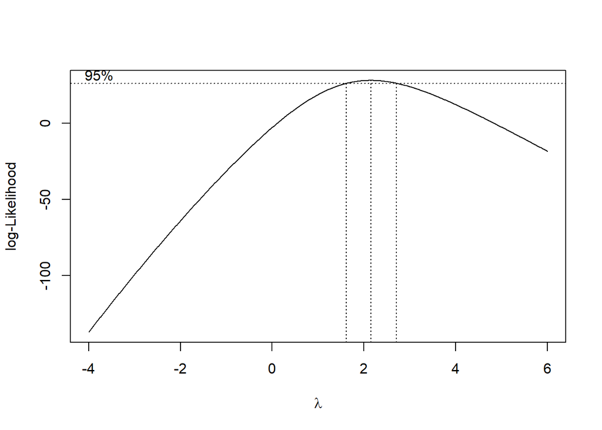

```r
index <- seq(1:70)
bc = boxcox(dt_stas1~index, lambda = seq(-4,6,by=0.01))
```

```r
#Nilai Rounded Lambda
lambda <- bc$x[which.max(bc$y)]
lambda
```

```
## [1] 2.15
```

```r
#SK
bc$x[bc$y > max(bc$y) - 1/2 * qchisq(.95,1)]
```

```
##   [1] 1.63 1.64 1.65 1.66 1.67 1.68 1.69 1.70 1.71 1.72 1.73 1.74 1.75 1.76 1.77
##  [16] 1.78 1.79 1.80 1.81 1.82 1.83 1.84 1.85 1.86 1.87 1.88 1.89 1.90 1.91 1.92
##  [31] 1.93 1.94 1.95 1.96 1.97 1.98 1.99 2.00 2.01 2.02 2.03 2.04 2.05 2.06 2.07
##  [46] 2.08 2.09 2.10 2.11 2.12 2.13 2.14 2.15 2.16 2.17 2.18 2.19 2.20 2.21 2.22
##  [61] 2.23 2.24 2.25 2.26 2.27 2.28 2.29 2.30 2.31 2.32 2.33 2.34 2.35 2.36 2.37
##  [76] 2.38 2.39 2.40 2.41 2.42 2.43 2.44 2.45 2.46 2.47 2.48 2.49 2.50 2.51 2.52
##  [91] 2.53 2.54 2.55 2.56 2.57 2.58 2.59 2.60 2.61 2.62 2.63 2.64 2.65 2.66 2.67
## [106] 2.68 2.69 2.70 2.71
```

Gambar di atas menunjukkan nilai *rounded value* ($\lambda$) optimum sebesar **2,15** dan pada selang kepercayaan 95% nilai memiliki batas bawah **1,63** dan batas atas **2,71**. Selang tersebut tidak memuat nilai satu sehingga dapat dikatakan bahwa data bangkitan tidak stasioner dalam ragam.

#### Bagian 2

```r
dt_stas2 <- stas[1:150] |> ts()
mean(dt_stas2)
```

```
## [1] 157.9333
```

```r
var(dt_stas2)
```

```
## [1] 3743.324
```

#### Plot Time Series

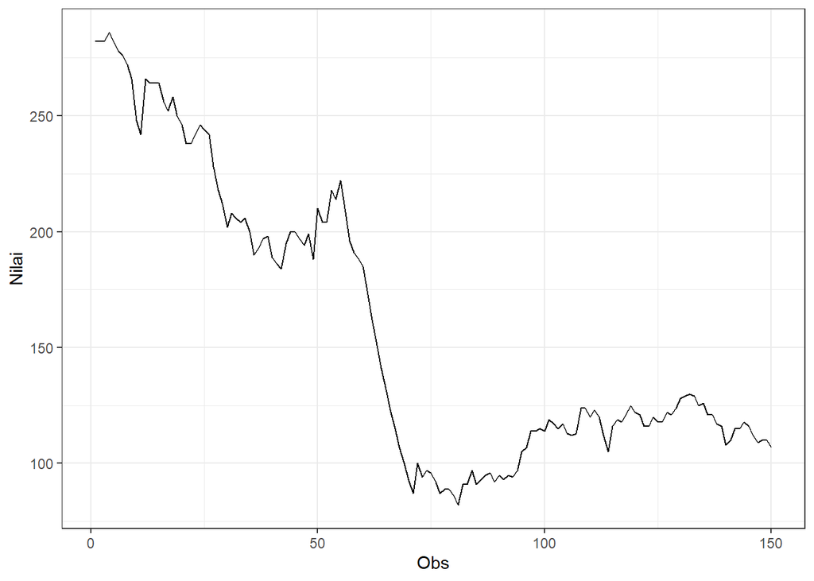

```r
dt_stas2 |> as_tsibble() |>
  ggplot(aes(x = index, y = value)) +
  geom_line() + theme_bw() +
  xlab("Obs") + ylab("Nilai")
```

Plot deret waktu di atas menunjukkan bahwa data tidak stasioner dalam rataan, ditandai dengan data yang tidak menyebar di sekitar nilai tengahnya. Selain itu, data cenderung tidak stasioner dalam ragam, ditandai dengan lebar pita yang cenderung berbeda.